# Developmental differences in learningfrom large but rare losses

This notebook contains exploratory analyses of behavioral data collected to investigate the relationship between risk taking behavior and probabilistic learning.

The sample consists of three age groups: kids, teens and adults and we hypothesize that sensitivity to learn from high variance feedback improves with age (and this is related to better risky decisions).

Subjects completed a probabilistic learning task in the scanner, a risky decision making task (BART) outside the scanner and numerous questionnaires. The focus of this notebook is on the first task.

The plan of analysis is to establish that adults are more sensitive to high variance feedback in the probabilistic learning task and relate this (modeled) sensitivity to behavior both in BART and other self-reported risky behaviors. Details of correlations are found [here](https://zenkavi.github.io/DevStudy_Analyses/output/reports/DevStudy_Other_Behavior.nb.html)

# Sample info

First let’s get a sense of the sample. Here is how many subjects we have who have complete datasets for the probabilistic learning task and their age break downs.

```r
machine_game_data_clean %>%
  group_by(age_group) %>%
  summarise(min_age = min(calc_age),
            mean_age = mean(calc_age),
            sd_age = sd(calc_age),
            max_age = max(calc_age),
            n = ceiling(n()/180))
```

| age_group | min_age | mean_age | sd_age | max_age | n |
| --- | --- | --- | --- | --- | --- |
| kid | 8.81 | 11.02624 | 1.234727 | 12.99 | 29 |
| teen | 13.64 | 16.96120 | 1.946810 | 19.96 | 25 |
| adult | 25.05 | 27.88600 | 1.581853 | 30.80 | 20 |

# Performance in RL task

This task is a modified Iowa Gambling Task. Subjects are presented with a fractal in each trial. The fractals represent different machines (single-armed bandits). Subjects choose to play or pass in each trial. Each machine yields a probabilistic reward. There are four machines in total. Two with positive and two with negative expected value. One of each of these machines has a low variance reward schedule while the other has a high variance reward schedule.

- One machine gives $5 90% of the time and -$495 %10 of the time
- One machine gives -$5 90% of the time and $495 %10 of the time
- One machine gives $10 50% of the time and -$100 %50 of the time
- One machine gives -$10 50% of the time and $100 %50 of the time

## Points earned

Performance in this task can be assessed by looking at the total number of points subjects make at the end of task. The following graph shows that adults collect more points in this task compared to kids.

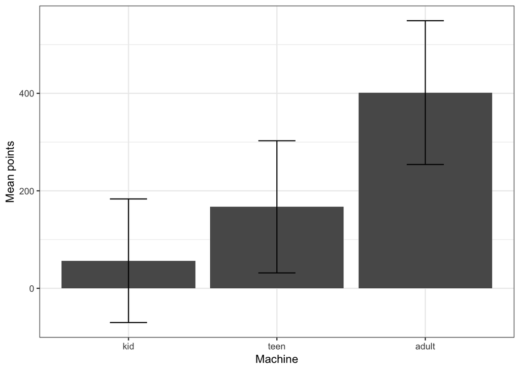

```r
machine_game_data_clean %>%
  group_by(Sub_id, facet_labels) %>%
  summarise(total_points = sum(Points_earned)) %>%
  do(assign.age.info(.)) %>%
  group_by(age_group) %>%
  summarise(mean_points = mean(total_points),
            sem_points = sem(total_points)) %>%
  ggplot(aes(age_group, mean_points))+
  geom_bar(stat='identity', position = position_dodge((0.9)))+
  geom_errorbar(aes(ymin=mean_points-sem_points, ymax=mean_points+sem_points), position = position_dodge(0.9), width=0.25)+
  theme_bw()+
  xlab('Machine')+
  ylab('Mean points')+
  labs(fill='Age group')
```

This difference is statistically significant: adults earn more points compared to the kids.

```r
tmp = machine_game_data_clean %>%
  group_by(Sub_id) %>%
  summarise(total_points = sum(Points_earned)) %>%
  do(assign.age.info(.))

summary(lm(total_points~age_group, data=tmp))
```

```
Call:
lm(formula = total_points ~ age_group, data = tmp)

Residuals:
    Min      1Q  Median      3Q     Max
-2591.0  -946.9   -47.5  1108.7  2551.2

Coefficients:
               Estimate Std. Error t value Pr(>|t|)
(Intercept)       226.2      245.4   0.922 0.359806
age_groupteen     442.6      360.7   1.227 0.223858
age_groupadult   1379.8      384.1   3.592 0.000601 ***
---
Signif. codes:  0 '***' 0.001 '**' 0.01 '*' 0.05 '.' 0.1 ' ' 1

Residual standard error: 1322 on 71 degrees of freedom
Multiple R-squared:  0.1552,    Adjusted R-squared:  0.1314
F-statistic: 6.519 on 2 and 71 DF,  p-value: 0.002515
```

On average each group earned:

```r
tmp %>%
  group_by(age_group) %>%
  summarise(mean_points = mean(total_points))
```

| age_group | mean_points |
| --- | --- |
| kid | 226.2069 |
| teen | 668.8000 |
| adult | 1606.0000 |

Since we are interested in the age differences between sensitivity to different feedback schedules, **we should show that this difference in performance exists especially for the high variance feedback condition(s)**. Here is the plot of performance (total points earned) broken down by conditions.

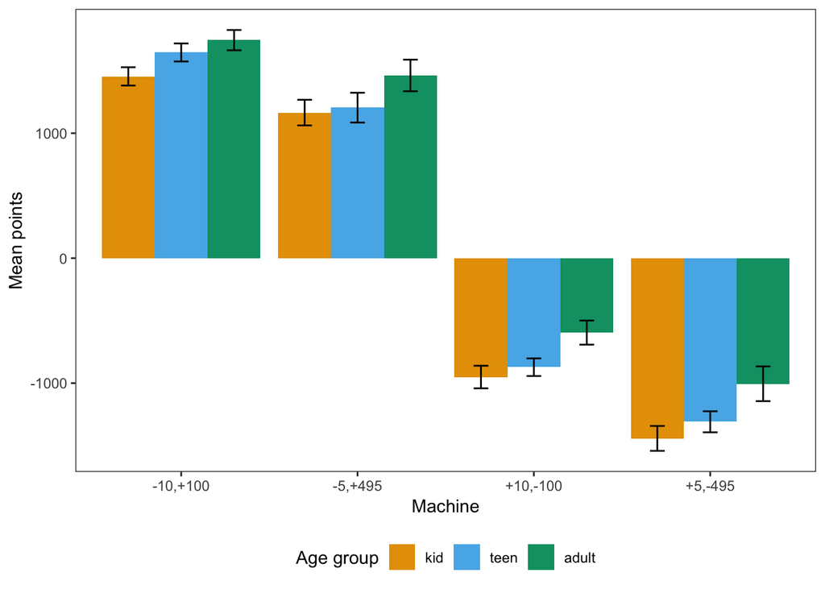

```r
machine_game_data_clean %>%
  group_by(Sub_id, facet_labels) %>%
  summarise(total_points = sum(Points_earned)) %>%
  do(assign.age.info(.)) %>%
  group_by(age_group, facet_labels) %>%
  summarise(mean_points = mean(total_points),
            sem_points = sem(total_points)) %>%
  ggplot(aes(facet_labels, mean_points, fill=age_group))+
  geom_bar(stat='identity', position = position_dodge((0.9)))+
  geom_errorbar(aes(ymin=mean_points-sem_points, ymax=mean_points+sem_points), position = position_dodge(0.9), width=0.25)+
  # theme_bw()+
  xlab('Machine')+
  ylab('Mean points')+
  labs(fill='Age group')
```

```r
ggsave("Points_earned.jpeg", device = "jpeg", path = fig_path, width = 7, height = 5, units = "in", dpi = 450)
```

Running separate models for positive and negative EV machines for ease of interpretation.

```r
tmp <- machine_game_data_clean %>%
  group_by(Sub_id, facet_labels) %>%
  summarise(total_points = sum(Points_earned)) %>%
  do(assign.age.info(.))
```

```r
summary(lm(total_points ~ age_group*facet_labels, data = tmp %>% filter(facet_labels %in% c("-10,+100", "-5,+495"))))
```

```
Call:
lm(formula = total_points ~ age_group * facet_labels, data = tmp %>%
    filter(facet_labels %in% c("-10,+100", "-5,+495")))

Residuals:
    Min      1Q  Median      3Q     Max
-1477.0  -297.2   144.8   329.5   813.0

Coefficients:
                                   Estimate Std. Error t value Pr(>|t|)
(Intercept)                        1454.483     89.652  16.224   <2e-16
age_groupteen                       191.517    131.761   1.454   0.1483
age_groupadult                      290.017    140.327   2.067   0.0406
facet_labels-5,+495                -289.655    126.787  -2.285   0.0238
age_groupteen:facet_labels-5,+495  -151.945    186.338  -0.815   0.4162
age_groupadult:facet_labels-5,+495    7.155    198.453   0.036   0.9713

(Intercept)                        ***
age_groupteen
age_groupadult                     *
facet_labels-5,+495                *
age_groupteen:facet_labels-5,+495
age_groupadult:facet_labels-5,+495
---
Signif. codes:  0 '***' 0.001 '**' 0.01 '*' 0.05 '.' 0.1 ' ' 1

Residual standard error: 482.8 on 142 degrees of freedom
Multiple R-squared:  0.164, Adjusted R-squared:  0.1346
F-statistic: 5.572 on 5 and 142 DF,  p-value: 0.000102
```

In the negative EV machines there is again a main effect for the high variance machine: Everyone losses fewer points in the low variance condition. There is also a main effect for adults: Adults perform better than kids for both negative EV machines.

```r
summary(lm(total_points ~ age_group*facet_labels, data = tmp %>% filter(facet_labels %in% c("+10,-100", "+5,-495"))))
```

```
Call:
lm(formula = total_points ~ age_group * facet_labels, data = tmp %>%
    filter(facet_labels %in% c("+10,-100", "+5,-495")))

Residuals:
     Min       1Q   Median       3Q      Max
-1290.00  -373.45     1.72   402.95  1017.07

Coefficients:
                                   Estimate Std. Error t value Pr(>|t|)
(Intercept)                         -951.03      89.33 -10.646  < 2e-16
age_groupteen                         78.63     131.29   0.599 0.550156
age_groupadult                       355.53     139.82   2.543 0.012069
facet_labels+5,-495                 -491.03     126.33  -3.887 0.000155
age_groupteen:facet_labels+5,-495     54.23     185.67   0.292 0.770631
age_groupadult:facet_labels+5,-495    81.53     197.74   0.412 0.680714

(Intercept)                        ***
age_groupteen
age_groupadult                     *
facet_labels+5,-495                ***
age_groupteen:facet_labels+5,-495
age_groupadult:facet_labels+5,-495
---
Signif. codes:  0 '***' 0.001 '**' 0.01 '*' 0.05 '.' 0.1 ' ' 1

Residual standard error: 481 on 142 degrees of freedom
Multiple R-squared:  0.2572,    Adjusted R-squared:  0.2311
F-statistic: 9.835 on 5 and 142 DF,  p-value: 4.331e-08
```

**So the age diffence in performance is driven by difference in performance in negative EV machines. The question is what difference in behavior in these conditions is leading to this difference in performance?**

To anticipate possible cognitive processes that will be parameterized in RL models differences can lie in: how quickly the groups learn the probabilities, how much weight they put on the outcomes and/or how much like an optimal agent they behave.

## Proportion of playing

The first thing we can look at is how often subjects play versus pass. It’s hard to see any age differences when we just look at frequency of overall playing as below.

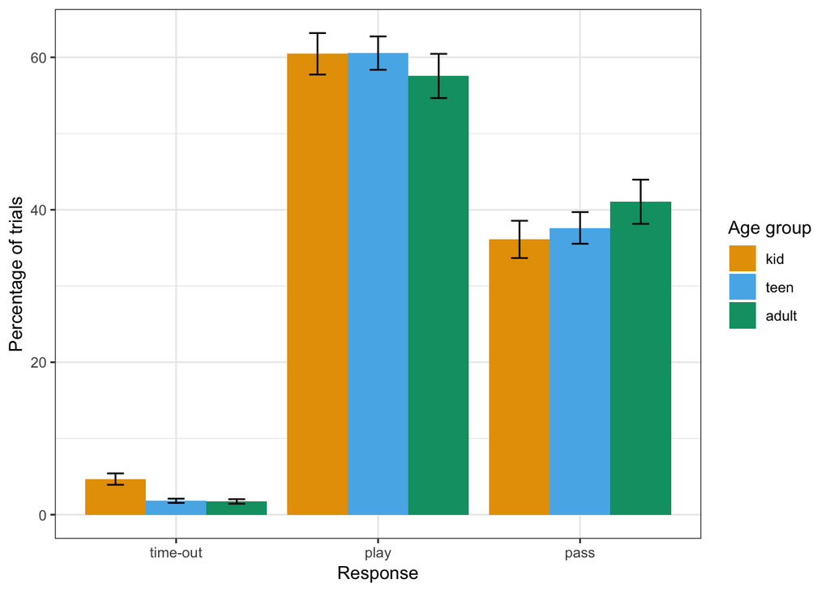

```r
machine_game_data_clean %>%
  group_by(Sub_id, Response) %>%
  tally %>%
  group_by(Sub_id) %>%
  mutate(pct=(100*n)/sum(n)) %>%
  do(assign.age.info(.)) %>%
  group_by(age_group, Response) %>%
  dplyr::summarise(mean_pct = mean(pct),
            sem_pct = sem(pct)) %>%
  ggplot(aes(Response, mean_pct, fill = age_group))+
  geom_bar(stat='identity', position = position_dodge(0.9))+
  geom_errorbar(aes(ymin = mean_pct - sem_pct, ymax = mean_pct + sem_pct), position = position_dodge(width = 0.9), width=0.25)+
  theme_bw()+
  ylab('Percentage of trials')+
  labs(fill = 'Age group')
```

It is also not immediately apparent how to translate this to better performance/learning in this task but one way to think about it: If people learned perfectly they should play half of the time (always for the positive expected value trial and never for the negative expected value trials). The fact that all play proportions are above 50% suggests that nobody learns perfectly and that adults might be closest to it. But this is very crude and a better way to look at it would be to see

1. how this depends on the different machines and
2. how it changes throughout the task.

To get a better sense of overall behavior in different contingency states we break this proportion of playing down by machines.

Now we can see age differences in playing frequency in different conditions, particularly in the negative expected value machines (bottom row).

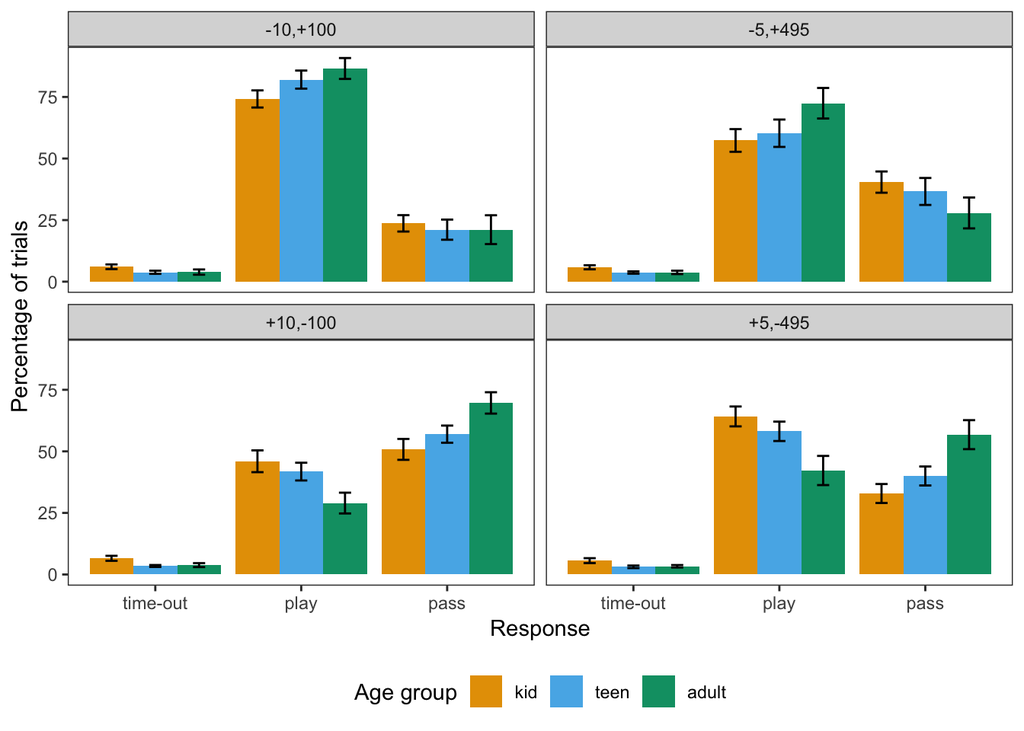

```r
machine_game_data_clean %>%
  group_by(Sub_id, facet_labels, Response) %>%
  tally %>%
  group_by(Sub_id, facet_labels) %>%
  mutate(pct=(100*n)/sum(n)) %>%
  do(assign.age.info(.)) %>%
  group_by(age_group, facet_labels, Response) %>%
 summarise(mean_pct = mean(pct),
            sem_pct = sem(pct)) %>%
  ggplot(aes(Response, mean_pct, fill = age_group))+
  geom_bar(stat='identity', position = position_dodge(0.9))+
  geom_errorbar(aes(ymin = mean_pct - sem_pct, ymax = mean_pct + sem_pct), position = position_dodge(width = 0.9), width=0.25)+
  ylab('Percentage of trials')+
  facet_wrap(~facet_labels)+
  labs(fill = 'Age group')
```

```r
ggsave("Prop_played.jpeg", device = "jpeg", path = fig_path, width = 8, height = 5, units = "in", dpi = 450)
```

The differences in points earned map directly on to proportion of choosing to play each machine:

- Adults play less than kids for both negative EV machines.
- Everyone plays the high var positive EV machine less than the low var positive EV machine.
- Everyone plays the low var negative EV machines less than the low var positive EV machine.

```r
tmp <- machine_game_data_clean %>%
  group_by(Sub_id, facet_labels, Response) %>%
  tally %>%
  group_by(Sub_id, facet_labels) %>%
  mutate(pct_play=(100*n)/sum(n)) %>%
  filter(Response == 'play') %>%
  do(assign.age.info(.))

summary(lmer(pct_play ~ age_group*facet_labels + (1|Sub_id), data = tmp))
```

```
Linear mixed model fit by REML ['lmerMod']
Formula: pct_play ~ age_group * facet_labels + (1 | Sub_id)
   Data: tmp

REML criterion at convergence: 2602.4

Scaled residuals:
     Min       1Q   Median       3Q      Max
-2.66682 -0.69780 -0.00607  0.71675  1.97256

Random effects:
 Groups   Name        Variance Std.Dev.
 Sub_id   (Intercept)  61.23    7.825
 Residual             436.76   20.899
Number of obs: 296, groups:  Sub_id, 74

Fixed effects:
                                    Estimate Std. Error t value
(Intercept)                           74.187      4.144  17.903
age_groupteen                          7.857      6.090   1.290
age_groupadult                        12.368      6.486   1.907
facet_labels-5,+495                  -16.853      5.488  -3.071
facet_labels+10,-100                 -28.214      5.488  -5.141
facet_labels+5,-495                  -10.008      5.488  -1.824
age_groupteen:facet_labels-5,+495     -4.924      8.066  -0.611
age_groupadult:facet_labels-5,+495     2.742      8.591   0.319
age_groupteen:facet_labels+10,-100   -12.052      8.066  -1.494
age_groupadult:facet_labels+10,-100  -29.341      8.591  -3.416
age_groupteen:facet_labels+5,-495    -13.903      8.066  -1.724
age_groupadult:facet_labels+5,-495   -34.325      8.591  -3.996

Correlation of Fixed Effects:
                  (Intr) ag_grpt ag_grpd f_-5,+ f_+10, f_+5,-
age_grouptn       -0.680
age_gropdlt       -0.639  0.435
fct_-5,+495       -0.662  0.451   0.423
fc_+10,-100       -0.662  0.451   0.423   0.500
fct_+5,-495       -0.662  0.451   0.423   0.500  0.500
ag_grpt:_-5,+495   0.451 -0.662  -0.288  -0.680 -0.340 -0.340
ag_grpd:_-5,+495   0.423 -0.288  -0.662  -0.639 -0.319 -0.319
```

[output cut: 13 more lines]

```
ag_grpd:_+10,-100  0.217            0.500            0.435
ag_grpt:_+5,-495   0.500            0.217            0.500
ag_grpd:_+5,-495   0.217            0.500            0.217
                  ag_grpd:_+10,-100 ag_grpt:_+5,-495
age_grouptn
age_gropdlt
fct_-5,+495
fc_+10,-100
fct_+5,-495
ag_grpt:_-5,+495
ag_grpd:_-5,+495
ag_grpt:_+10,-100
ag_grpd:_+10,-100
ag_grpt:_+5,-495   0.217
ag_grpd:_+5,-495   0.500             0.435
```

This is not surprising given what the number of points earned already showed. But now that we are looking at a behavioral measure instead of an outcome measure we might be able to quantify constructs of interest like sensitivity to variance or sensitivity to the expected values of the machines.

As a first step to translate raw playing behavior to learning I recoded the choices to be `correct` when a subject chooses to play a positive expected value machine and pass a negative expected value machine and `incorrect` when the reverse is true. If a subject is learning they should be learning to play the positive expected machines and to pass the others.

## Learning

Recoding the behavior in this way gave a clearer picture of the age difference *in learning of optimal behavior* between the conditions. Specifically we can now look at how the probability of a correct choice changes for each age group in each condition across trials.

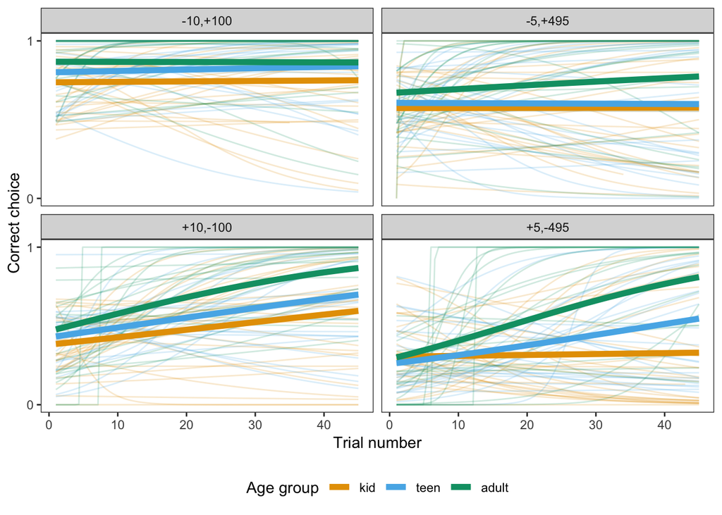

```r
machine_game_data_clean %>%
  group_by(Sub_id, facet_labels) %>%
  mutate(rel_tm = 1:n()) %>%
  # ggplot(aes(scale(Trial_number), correct1_incorrect0))+
    ggplot(aes(rel_tm, correct1_incorrect0))+
  geom_line(aes(group = Sub_id, col= factor(age_group, levels=c('kid', 'teen', 'adult'))),stat='smooth', method = 'glm', method.args = list(family = "binomial"), se = FALSE, alpha=0.2)+
  geom_line(aes(col= factor(age_group, levels=c('kid', 'teen', 'adult'))),stat='smooth', method = 'glm', method.args = list(family = "binomial"), se = FALSE, alpha=1, size=2)+
  facet_wrap(~facet_labels)+
  theme_bw()+
  # xlab("Relative trial number")+
  xlab("Trial number")+
  scale_y_continuous(breaks=c(0,1))+
  labs(col="Age group")+
  ylab('Correct choice')+
  theme(legend.position = "bottom",
        panel.grid = element_blank())
```

```r
ggsave("Learning.jpeg", device = "jpeg", path = fig_path, width = 8, height = 5, units = "in", dpi = 450)
```

There is no significant change in behavior across time for the positive EV machines while there is for the negative EV machines. **If the initial behavior is exploratory playing this pattern would indicate ‘learning’ occuring for both types of machines.**

```r
summary(glmer(correct1_incorrect0 ~ age_group*scale(Trial_number)+(1|Sub_id), data = machine_game_data_clean %>% filter(facet_labels %in% c('-10,+100', '-5,+495')), family=binomial))
```

```
Generalized linear mixed model fit by maximum likelihood (Laplace
  Approximation) [glmerMod]
 Family: binomial  ( logit )
Formula: correct1_incorrect0 ~ age_group * scale(Trial_number) + (1 |
    Sub_id)
   Data:
machine_game_data_clean %>% filter(facet_labels %in% c("-10,+100",
    "-5,+495"))

     AIC      BIC   logLik deviance df.resid
  6692.1   6739.7  -3339.1   6678.1     6632

Scaled residuals:
    Min      1Q  Median      3Q     Max
-5.8537 -0.7594  0.3049  0.5888  1.8805

Random effects:
 Groups Name        Variance Std.Dev.
 Sub_id (Intercept) 1.589    1.26
Number of obs: 6639, groups:  Sub_id, 74

Fixed effects:
                                    Estimate Std. Error z value Pr(>|z|)
(Intercept)                         0.835801   0.239608   3.488 0.000486
age_groupteen                       0.360334   0.352995   1.021 0.307354
age_groupadult                      1.117174   0.381439   2.929 0.003402
scale(Trial_number)                -0.006341   0.044993  -0.141 0.887930
age_groupteen:scale(Trial_number)   0.019100   0.068541   0.279 0.780505
age_groupadult:scale(Trial_number)  0.136594   0.081872   1.668 0.095240

(Intercept)                        ***
age_groupteen
age_groupadult                     **
scale(Trial_number)
age_groupteen:scale(Trial_number)
age_groupadult:scale(Trial_number) .
---
Signif. codes:  0 '***' 0.001 '**' 0.01 '*' 0.05 '.' 0.1 ' ' 1

Correlation of Fixed Effects:
             (Intr) ag_grpt ag_grpd sc(T_) ag_grpt:(T_)
age_grouptn  -0.678
age_gropdlt  -0.627  0.426
scl(Trl_nm)   0.001 -0.001  -0.001
ag_grpt:(T_) -0.001  0.001   0.001  -0.656
ag_grpd:(T_)  0.000  0.001   0.011  -0.550  0.361
```

```r
summary(glmer(correct1_incorrect0 ~ age_group*scale(Trial_number)+(1|Sub_id), data = machine_game_data_clean %>% filter(facet_labels %in% c('+10,-100', '+5,-495')), family=binomial))
```

```
Generalized linear mixed model fit by maximum likelihood (Laplace
  Approximation) [glmerMod]
 Family: binomial  ( logit )
Formula: correct1_incorrect0 ~ age_group * scale(Trial_number) + (1 |
    Sub_id)
   Data:
machine_game_data_clean %>% filter(facet_labels %in% c("+10,-100",
    "+5,-495"))

     AIC      BIC   logLik deviance df.resid
  7791.8   7839.4  -3888.9   7777.8     6644

Scaled residuals:
    Min      1Q  Median      3Q     Max
-3.8023 -0.7970 -0.1750  0.7745  4.0278

Random effects:
 Groups Name        Variance Std.Dev.
 Sub_id (Intercept) 1.047    1.023
Number of obs: 6651, groups:  Sub_id, 74

Fixed effects:
                                   Estimate Std. Error z value Pr(>|z|)
(Intercept)                        -0.53571    0.19620  -2.730  0.00633
age_groupteen                       0.48516    0.28734   1.688  0.09132
age_groupadult                      1.28166    0.30763   4.166 3.10e-05
scale(Trial_number)                 0.25678    0.04433   5.793 6.93e-09
age_groupteen:scale(Trial_number)   0.19207    0.06450   2.978  0.00290
age_groupadult:scale(Trial_number)  0.60405    0.07848   7.697 1.40e-14

(Intercept)                        **
age_groupteen                      .
age_groupadult                     ***
scale(Trial_number)                ***
age_groupteen:scale(Trial_number)  **
age_groupadult:scale(Trial_number) ***
---
Signif. codes:  0 '***' 0.001 '**' 0.01 '*' 0.05 '.' 0.1 ' ' 1

Correlation of Fixed Effects:
             (Intr) ag_grpt ag_grpd sc(T_) ag_grpt:(T_)
age_grouptn  -0.683
age_gropdlt  -0.638  0.436
scl(Trl_nm)  -0.009  0.006   0.006
ag_grpt:(T_)  0.006 -0.005  -0.004  -0.687
ag_grpd:(T_)  0.003 -0.002   0.034  -0.564  0.388
```

Looking at learning effects separately for each machine:

Adults are more likely to make correct decisions in low var positive EV machine.

```r
summary(glmer(correct1_incorrect0 ~ age_group*scale(Trial_number)+(1|Sub_id), data = machine_game_data_clean %>% filter(facet_labels %in% c('-10,+100')), family=binomial))
```

```
Generalized linear mixed model fit by maximum likelihood (Laplace
  Approximation) [glmerMod]
 Family: binomial  ( logit )
Formula: correct1_incorrect0 ~ age_group * scale(Trial_number) + (1 |
    Sub_id)
   Data:
machine_game_data_clean %>% filter(facet_labels %in% c("-10,+100"))

     AIC      BIC   logLik deviance df.resid
  2749.0   2791.7  -1367.5   2735.0     3313

Scaled residuals:
    Min      1Q  Median      3Q     Max
-5.9273  0.1141  0.2178  0.4711  1.9148

Random effects:
 Groups Name        Variance Std.Dev.
 Sub_id (Intercept) 2.424    1.557
Number of obs: 3320, groups:  Sub_id, 74

Fixed effects:
                                   Estimate Std. Error z value Pr(>|z|)
(Intercept)                         1.43430    0.30300   4.734  2.2e-06
age_groupteen                       0.66864    0.44990   1.486  0.13723
age_groupadult                      1.51209    0.49771   3.038  0.00238
scale(Trial_number)                 0.03214    0.06979   0.460  0.64518
age_groupteen:scale(Trial_number)   0.08535    0.11070   0.771  0.44069
age_groupadult:scale(Trial_number) -0.03529    0.13146  -0.268  0.78835

(Intercept)                        ***
age_groupteen
age_groupadult                     **
scale(Trial_number)
age_groupteen:scale(Trial_number)
age_groupadult:scale(Trial_number)
---
Signif. codes:  0 '***' 0.001 '**' 0.01 '*' 0.05 '.' 0.1 ' ' 1

Correlation of Fixed Effects:
             (Intr) ag_grpt ag_grpd sc(T_) ag_grpt:(T_)
age_grouptn  -0.667
age_gropdlt  -0.597  0.411
scl(Trl_nm)   0.005 -0.004  -0.003
ag_grpt:(T_) -0.003  0.012   0.003  -0.631
ag_grpd:(T_) -0.003  0.002   0.001  -0.531  0.335
```

```r
summary(glmer(correct1_incorrect0 ~ age_group*scale(Trial_number)+(1|Sub_id), data = machine_game_data_clean %>% filter(facet_labels %in% c('-5,+495')), family=binomial))
```

```
Generalized linear mixed model fit by maximum likelihood (Laplace
  Approximation) [glmerMod]
 Family: binomial  ( logit )
Formula: correct1_incorrect0 ~ age_group * scale(Trial_number) + (1 |
    Sub_id)
   Data:
machine_game_data_clean %>% filter(facet_labels %in% c("-5,+495"))

     AIC      BIC   logLik deviance df.resid
  3523.1   3565.8  -1754.5   3509.1     3312

Scaled residuals:
    Min      1Q  Median      3Q     Max
-4.3340 -0.7119  0.2991  0.5720  3.9680

Random effects:
 Groups Name        Variance Std.Dev.
 Sub_id (Intercept) 2.152    1.467
Number of obs: 3319, groups:  Sub_id, 74

Fixed effects:
                                   Estimate Std. Error z value Pr(>|z|)
(Intercept)                        0.430022   0.281526   1.527   0.1266
age_groupteen                      0.170332   0.414035   0.411   0.6808
age_groupadult                     1.017752   0.447168   2.276   0.0228 *
scale(Trial_number)                0.025711   0.064116   0.401   0.6884
age_groupteen:scale(Trial_number)  0.009261   0.096280   0.096   0.9234
age_groupadult:scale(Trial_number) 0.286436   0.111048   2.579   0.0099 **
---
Signif. codes:  0 '***' 0.001 '**' 0.01 '*' 0.05 '.' 0.1 ' ' 1

Correlation of Fixed Effects:
             (Intr) ag_grpt ag_grpd sc(T_) ag_grpt:(T_)
age_grouptn  -0.680
age_gropdlt  -0.629  0.428
scl(Trl_nm)   0.003 -0.002  -0.002
ag_grpt:(T_) -0.002  0.002   0.001  -0.666
ag_grpd:(T_) -0.001  0.001   0.023  -0.577  0.385
```

All groups show improvement across trials for the low var negative EV machine but adults learn faster than kids and teens.

```r
summary(glmer(correct1_incorrect0 ~ age_group*scale(Trial_number)+(1|Sub_id), data = machine_game_data_clean %>% filter(facet_labels %in% c('+10,-100')), family=binomial))
```

```
Generalized linear mixed model fit by maximum likelihood (Laplace
  Approximation) [glmerMod]
 Family: binomial  ( logit )
Formula: correct1_incorrect0 ~ age_group * scale(Trial_number) + (1 |
    Sub_id)
   Data:
machine_game_data_clean %>% filter(facet_labels %in% c("+10,-100"))

     AIC      BIC   logLik deviance df.resid
  3941.9   3984.6  -1963.9   3927.9     3316

Scaled residuals:
    Min      1Q  Median      3Q     Max
-4.4795 -0.8657  0.3608  0.7405  3.7111

Random effects:
 Groups Name        Variance Std.Dev.
 Sub_id (Intercept) 1.039    1.019
Number of obs: 3323, groups:  Sub_id, 74

Fixed effects:
                                   Estimate Std. Error z value Pr(>|z|)
(Intercept)                        -0.11697    0.20051  -0.583 0.559665
age_groupteen                       0.46945    0.29375   1.598 0.110018
age_groupadult                      1.19288    0.31646   3.769 0.000164
scale(Trial_number)                 0.28413    0.06329   4.489 7.14e-06
age_groupteen:scale(Trial_number)   0.07164    0.09125   0.785 0.432409
age_groupadult:scale(Trial_number)  0.41654    0.10770   3.868 0.000110

(Intercept)
age_groupteen
age_groupadult                     ***
scale(Trial_number)                ***
age_groupteen:scale(Trial_number)
age_groupadult:scale(Trial_number) ***
---
Signif. codes:  0 '***' 0.001 '**' 0.01 '*' 0.05 '.' 0.1 ' ' 1

Correlation of Fixed Effects:
             (Intr) ag_grpt ag_grpd sc(T_) ag_grpt:(T_)
age_grouptn  -0.683
age_gropdlt  -0.635  0.434
scl(Trl_nm)   0.000  0.001   0.001
ag_grpt:(T_)  0.000  0.007   0.000  -0.693
ag_grpd:(T_) -0.002  0.002   0.054  -0.586  0.407
```

Kids don’t show learning across trials for the high var negative EV machine but adults and teens do.

```r
summary(glmer(correct1_incorrect0 ~ age_group*scale(Trial_number)+(1|Sub_id), data = machine_game_data_clean%>% filter(facet_labels %in% c('+5,-495')), family=binomial))
```

```
Generalized linear mixed model fit by maximum likelihood (Laplace
  Approximation) [glmerMod]
 Family: binomial  ( logit )
Formula: correct1_incorrect0 ~ age_group * scale(Trial_number) + (1 |
    Sub_id)
   Data:
machine_game_data_clean %>% filter(facet_labels %in% c("+5,-495"))

     AIC      BIC   logLik deviance df.resid
  3769.2   3812.0  -1877.6   3755.2     3321

Scaled residuals:
    Min      1Q  Median      3Q     Max
-2.9608 -0.6785 -0.3732  0.7556  3.7464

Random effects:
 Groups Name        Variance Std.Dev.
 Sub_id (Intercept) 1.246    1.116
Number of obs: 3328, groups:  Sub_id, 74

Fixed effects:
                                   Estimate Std. Error z value Pr(>|z|)
(Intercept)                        -0.96663    0.21941  -4.406 1.05e-05
age_groupteen                       0.48330    0.32039   1.508    0.131
age_groupadult                      1.34244    0.34305   3.913 9.11e-05
scale(Trial_number)                 0.03858    0.06522   0.591    0.554
age_groupteen:scale(Trial_number)   0.36695    0.09365   3.918 8.92e-05
age_groupadult:scale(Trial_number)  0.88273    0.11498   7.677 1.63e-14

(Intercept)                        ***
age_groupteen
age_groupadult                     ***
scale(Trial_number)
age_groupteen:scale(Trial_number)  ***
age_groupadult:scale(Trial_number) ***
---
Signif. codes:  0 '***' 0.001 '**' 0.01 '*' 0.05 '.' 0.1 ' ' 1

Correlation of Fixed Effects:
             (Intr) ag_grpt ag_grpd sc(T_) ag_grpt:(T_)
age_grouptn  -0.684
age_gropdlt  -0.640  0.438
scl(Trl_nm)  -0.003  0.002   0.002
ag_grpt:(T_)  0.001 -0.011  -0.001  -0.696
ag_grpd:(T_) -0.003  0.001   0.031  -0.567  0.397
```

### Grouping by learning

The thin lines in the above plot denote individual subjects. They vary largely from each other including within age groups. This highlights the amount of individual variability in learning behavior. Therefore, another and perhaps even more useful group classification in understanding behavioral differences for this sample is between “learner” and “non-learners.” These groups are operationally defined as subjects who have a positive or negative slope to their sigmoid curves in the above graph. The sign of the slope indicates the sigmoids direction while its magnitude the speed with which the curve towards the boundary. Thus, a positive slope implies that a subject was more likely to make a “correct” choice later in the task than they were earlier.

```r
get_learning_coef <- function(data){
  model = glm(correct1_incorrect0 ~ scale(Trial_number), family = binomial(link=logit), data = data)
  b0 = coef(model)[1]
  b1 = coef(model)[2]
  learnIndex = -b0/b1
  return(data.frame(b0, b1, learnIndex))
}
```

Defined in this manner we find

```r
tmp = machine_game_data_clean %>%
  group_by(Sub_id, facet_labels) %>%
  do(get_learning_coef(.)) %>%
  do(assign.age.info(.)) %>%
  mutate(learner = ifelse(b1>0,1,0))

with(tmp, table(learner, facet_labels, age_group))
```

```
, , age_group = kid

       facet_labels
learner -10,+100 -5,+495 +10,-100 +5,-495
      0       14      14       12      18
      1       15      15       17      11

, , age_group = teen

       facet_labels
learner -10,+100 -5,+495 +10,-100 +5,-495
      0       12      10        7      10
      1       13      15       18      15

, , age_group = adult

       facet_labels
learner -10,+100 -5,+495 +10,-100 +5,-495
      0       11       5        2       3
      1        9      15       18      17
```

```r
non_learners = tmp %>%
  #ONLY THE nEV machines
  filter(facet_labels %in% c("+5,-495", "+10,-100")) %>%
  filter(learner == 0)

non_learners = unique(non_learners$Sub_id)
#non_learners

learner_info = data.frame(Sub_id = unique(machine_game_data_clean$Sub_id))

learner_info = learner_info %>%
  mutate(learner = ifelse(Sub_id %in% non_learners == FALSE, 1, 0),
         non_learner = ifelse(Sub_id %in% non_learners, 1, 0),
         Sub_id = paste0('sub-', Sub_id))

#write.csv(learner_info, '/Users/zeynepenkavi/Dropbox/PoldrackLab/DevStudy_ServerScripts/nistats/level_3/learner_info.csv', row.names = FALSE)

data.frame(Sub_id = unique(machine_game_data_clean$Sub_id)) %>%
  mutate(learner = ifelse(Sub_id %in% non_learners == FALSE, 1, 0),
         non_learner = ifelse(Sub_id %in% non_learners, 1, 0),
         age_group = ifelse(Sub_id<200000, "kid", ifelse(Sub_id>200000 & Sub_id<400000, "teen", "adult")),
         age_group = factor(age_group, levels = c("kid", "teen", "adult"))) %>%
  group_by(age_group)  %>%
  summarise(total_learners = sum(learner),
            total_non_learners = sum(non_learner))
```

| age_group | total_learners | total_non_learners |
| --- | --- | --- |
| kid | 8 | 21 |
| teen | 12 | 13 |
| adult | 16 | 4 |

### Variance vs. EV effects on learning

A subject-level measure of learning (the slope of the sigmoids) allows us to compare the effect of the two varying attributes (EV and variance) on learning. To do so we compared the difference in slopes between the two conditions of each attribute and computed the effect of EV and variance for each subject.

```r
ev_var_effect = tmp %>%
  select(Sub_id, b1, age_group, facet_labels) %>%
  #some adults have too large slopes (making the below effects unnecessarily large)
  filter(b1<10) %>%
  spread(facet_labels, b1) %>%
  mutate(ev_effect = (`+10,-100`+ `+5,-495`) - (`-10,+100`+ `-5,+495`), #row difference,
         var_effect = (`+5,-495` + `-5,+495`) - (`+10,-100`+ `-10,+100`) #col difference
         ) %>%
  select(Sub_id, age_group, ev_effect, var_effect) %>%
  gather(key, value, -Sub_id, -age_group) %>%
  mutate(learner = ifelse(Sub_id %in% non_learners, 0, 1))
```

A large ev effect suggests larger slope for negative ev machines compared to positive machines. A large var effect larger slope for high var machines than low var machines.

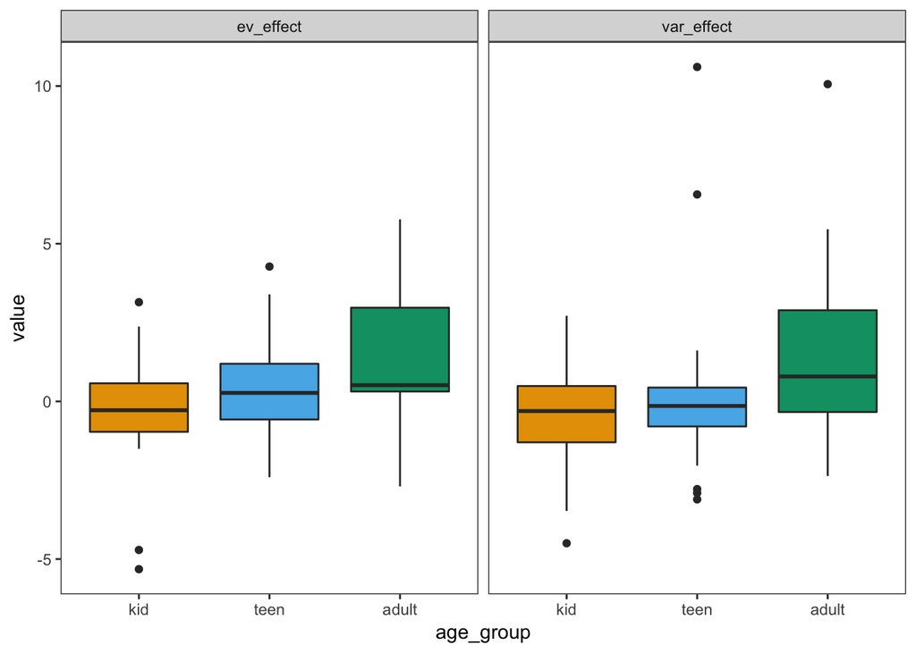

```r
ev_var_effect %>%
  ggplot(aes(age_group, value, fill=age_group))+
  geom_boxplot()+
  facet_wrap(~key)+
  theme(legend.position = "none")
```

Adults show both larger EV and var effects compared to kids. But var vs. ev effect does not differ from each other.

```r
summary(lm(value~key*age_group,ev_var_effect))
```

```
Call:
lm(formula = value ~ key * age_group, data = ev_var_effect)

Residuals:
    Min      1Q  Median      3Q     Max
-5.0166 -1.0664 -0.2405  0.7978 10.3753

Coefficients:
                             Estimate Std. Error t value Pr(>|t|)
(Intercept)                   -0.3035     0.4179  -0.726   0.4690
keyvar_effect                 -0.0679     0.5910  -0.115   0.9087
age_groupteen                  0.8327     0.6085   1.369   0.1735
age_groupadult                 1.7734     0.6930   2.559   0.0116 *
keyvar_effect:age_groupteen   -0.2317     0.8605  -0.269   0.7882
keyvar_effect:age_groupadult   0.3146     0.9800   0.321   0.7487
---
Signif. codes:  0 '***' 0.001 '**' 0.01 '*' 0.05 '.' 0.1 ' ' 1

Residual standard error: 2.211 on 132 degrees of freedom
  (10 observations deleted due to missingness)
Multiple R-squared:  0.1073,    Adjusted R-squared:  0.0735
F-statistic: 3.174 on 5 and 132 DF,  p-value: 0.00973
```

Correspondingly learners show larger effects of both variance and EV compared to non-learners. Again EV and var effects do not differ from each other.

```r
summary(lm(value~key*learner,ev_var_effect))
```

```
Call:
lm(formula = value ~ key * learner, data = ev_var_effect)

Residuals:
    Min      1Q  Median      3Q     Max
-5.1253 -1.1671 -0.2274  0.8102 10.3291

Coefficients:
                       Estimate Std. Error t value Pr(>|t|)
(Intercept)           -0.194736   0.366227  -0.532   0.5958
keyvar_effect         -0.074602   0.517924  -0.144   0.8857
learner                1.302826   0.537775   2.423   0.0167 *
keyvar_effect:learner -0.009257   0.760528  -0.012   0.9903
---
Signif. codes:  0 '***' 0.001 '**' 0.01 '*' 0.05 '.' 0.1 ' ' 1

Residual standard error: 2.228 on 134 degrees of freedom
  (10 observations deleted due to missingness)
Multiple R-squared:  0.08029,   Adjusted R-squared:  0.0597
F-statistic: 3.899 on 3 and 134 DF,  p-value: 0.01041
```

## Additional behavioral patterns

Though I focus on learning behavior and specifically difference in learning for the high variance negative EV machine there are other possible behavioral patterns that might also differ between the age groups. Here I list some examples.

### Initial exploration

Do people ‘explore’ the first 10 trials where the reward probabilities for each machine are presented?

They explore less when they encounter a loss early on. In the high var pos EV machine they get 4 (small) losses in a row; in the low var negative EV machine they get a moderate loss in the first trial.

```r
machine_game_data_clean %>%
  group_by(Sub_id, facet_labels) %>%
  slice(1:10) %>%
  summarise(num_explored = sum(ifelse(Response == "play", 1,0))) %>%
  do(assign.age.info(.)) %>%
  ungroup() %>%
  group_by(age_group, facet_labels) %>%
  summarise(mean_num_explored = mean(num_explored/10*100),
            sem_num_explored = sem(num_explored/10*100)) %>%
  ggplot(aes(facet_labels, mean_num_explored, fill = age_group))+
  geom_bar(stat="identity",position = position_dodge(0.9))+
  geom_errorbar(aes(ymax = mean_num_explored+sem_num_explored, ymin = mean_num_explored-sem_num_explored), position = position_dodge(width = 0.9), width=0.25)+
  theme(legend.title = element_blank())+
  ylab("Percentage of exploration")+
  xlab("")
```

[output not shown]

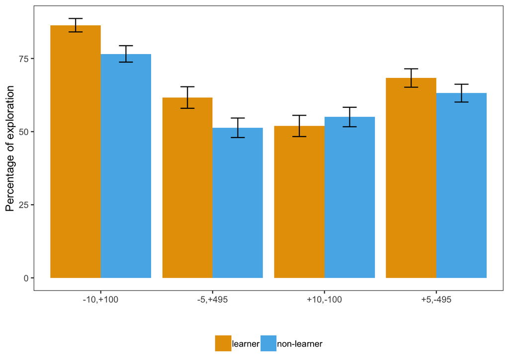

```r
tmp = machine_game_data_clean %>%
  group_by(Sub_id, facet_labels) %>%
  slice(1:10) %>%
  summarise(num_explored = sum(ifelse(Response == "play", 1,0))) %>%
  mutate(learner = ifelse(Sub_id %in% non_learners, "non-learner","learner"))
tmp %>%
  ungroup() %>%
  group_by(learner, facet_labels) %>%
  summarise(mean_num_explored = mean(num_explored/10*100),
            sem_num_explored = sem(num_explored/10*100)) %>%
  ggplot(aes(facet_labels, mean_num_explored, fill = learner))+
  geom_bar(stat="identity",position = position_dodge(0.9))+
  geom_errorbar(aes(ymax = mean_num_explored+sem_num_explored, ymin = mean_num_explored-sem_num_explored), position = position_dodge(width = 0.9), width=0.25)+
  theme(legend.title = element_blank())+
  ylab("Percentage of exploration")+
  xlab("")
```

lVAR pEV is explored more in the first 10 trials compared to the other machines and even more so for learners compared to non-learners.

```r
summary(lm(num_explored ~ learner*facet_labels, tmp))
```

```
Call:
lm(formula = num_explored ~ learner * facet_labels, data = tmp)

Residuals:
    Min      1Q  Median      3Q     Max
-5.6579 -1.1944 -0.1944  1.3611  4.8684

Coefficients:
                                        Estimate Std. Error t value
(Intercept)                              8.63889    0.32283  26.760
learnernon-learner                      -0.98099    0.45050  -2.178
facet_labels-5,+495                     -2.47222    0.45655  -5.415
facet_labels+10,-100                    -3.44444    0.45655  -7.544
facet_labels+5,-495                     -1.80556    0.45655  -3.955
learnernon-learner:facet_labels-5,+495  -0.05409    0.63711  -0.085
learnernon-learner:facet_labels+10,-100  1.28655    0.63711   2.019
learnernon-learner:facet_labels+5,-495   0.46345    0.63711   0.727
                                        Pr(>|t|)
(Intercept)                              < 2e-16 ***
learnernon-learner                        0.0303 *
facet_labels-5,+495                     1.29e-07 ***
facet_labels+10,-100                    5.98e-13 ***
facet_labels+5,-495                     9.65e-05 ***
learnernon-learner:facet_labels-5,+495    0.9324
learnernon-learner:facet_labels+10,-100   0.0444 *
learnernon-learner:facet_labels+5,-495    0.4676
---
Signif. codes:  0 '***' 0.001 '**' 0.01 '*' 0.05 '.' 0.1 ' ' 1

Residual standard error: 1.937 on 288 degrees of freedom
Multiple R-squared:  0.267, Adjusted R-squared:  0.2492
F-statistic: 14.99 on 7 and 288 DF,  p-value: < 2.2e-16
```

### Memory effect

How does performance change depending on the delay between the last time a machine was played?

Can we think of this as a ‘memory effect’? The more trials since the last time you have played a machine, the more forgetting/interference?

We find a negative effect of the play delay only for hVAR pEV. Perhaps the large reward participants experience lead to a more salient representation than the more frequent small losses. In contrast, both nEV are more likely to be correct the longer the delay possibly by allowing more time for integration.

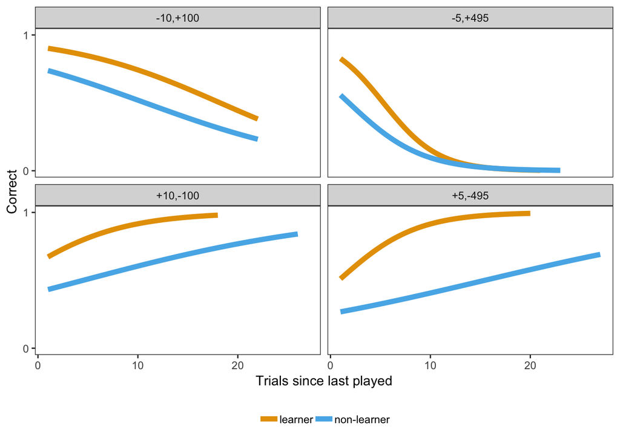

```r
tmp = machine_game_data_clean %>%
  group_by(Sub_id) %>%
  mutate(played_trial_number = ifelse(Response == "play", Trial_number, NA)) %>%
  mutate(played_trial_number = na.locf(played_trial_number, na.rm=F)) %>%
  filter(Trial_number > 1) %>%
  mutate(trials_since_last_played = Trial_number - lag(played_trial_number)) %>%
  mutate(learner = ifelse(Sub_id %in% non_learners, "non-learner","learner"))
tmp %>%
  ggplot(aes(trials_since_last_played, correct1_incorrect0, col = learner))+
  geom_line(stat='smooth', method = 'glm', method.args = list(family = "binomial"), alpha=1, size=2)+
  facet_wrap(~facet_labels)+
  theme(legend.title = element_blank())+
  xlab("Trials since last played")+
  ylab("Correct")+
  scale_y_continuous(breaks=c(0,1))
```

```r
summary(glmer(correct1_incorrect0 ~ trials_since_last_played*learner+(1|Sub_id),tmp %>% filter(facet_labels == "-10,+100"), family = binomial))
```

```
Generalized linear mixed model fit by maximum likelihood (Laplace
  Approximation) [glmerMod]
 Family: binomial  ( logit )
Formula: correct1_incorrect0 ~ trials_since_last_played * learner + (1 |
    Sub_id)
   Data: tmp %>% filter(facet_labels == "-10,+100")

     AIC      BIC   logLik deviance df.resid
  2665.6   2696.0  -1327.8   2655.6     3239

Scaled residuals:
    Min      1Q  Median      3Q     Max
-5.7470  0.1217  0.2207  0.4725  1.9370

Random effects:
 Groups Name        Variance Std.Dev.
 Sub_id (Intercept) 2.107    1.452
Number of obs: 3244, groups:  Sub_id, 74

Fixed effects:
                                            Estimate Std. Error z value
(Intercept)                                  2.79218    0.28962   9.641
trials_since_last_played                     0.03532    0.04081   0.866
learnernon-learner                          -1.45357    0.38418  -3.784
trials_since_last_played:learnernon-learner -0.06633    0.05582  -1.188
                                            Pr(>|z|)
(Intercept)                                  < 2e-16 ***
trials_since_last_played                    0.386746
learnernon-learner                          0.000155 ***
trials_since_last_played:learnernon-learner 0.234720
---
Signif. codes:  0 '***' 0.001 '**' 0.01 '*' 0.05 '.' 0.1 ' ' 1

Correlation of Fixed Effects:
            (Intr) trl___ lrnrn-
trls_snc_l_ -0.268
lrnrnn-lrnr -0.744  0.207
trls_sn__:-  0.200 -0.729 -0.274
```

```r
summary(glmer(correct1_incorrect0 ~ trials_since_last_played*learner+(1|Sub_id),tmp %>% filter(facet_labels == "-5,+495"), family = binomial))
```

```
Generalized linear mixed model fit by maximum likelihood (Laplace
  Approximation) [glmerMod]
 Family: binomial  ( logit )
Formula: correct1_incorrect0 ~ trials_since_last_played * learner + (1 |
    Sub_id)
   Data: tmp %>% filter(facet_labels == "-5,+495")

     AIC      BIC   logLik deviance df.resid
  3355.4   3385.8  -1672.7   3345.4     3239

Scaled residuals:
    Min      1Q  Median      3Q     Max
-5.0108 -0.7161  0.2996  0.5560  3.5240

Random effects:
 Groups Name        Variance Std.Dev.
 Sub_id (Intercept) 1.678    1.295
Number of obs: 3244, groups:  Sub_id, 74

Fixed effects:
                                            Estimate Std. Error z value
(Intercept)                                  1.90103    0.24892   7.637
trials_since_last_played                    -0.16442    0.04717  -3.485
learnernon-learner                          -1.50133    0.33865  -4.433
trials_since_last_played:learnernon-learner -0.01243    0.06162  -0.202
                                            Pr(>|z|)
(Intercept)                                 2.22e-14 ***
trials_since_last_played                    0.000491 ***
learnernon-learner                          9.28e-06 ***
trials_since_last_played:learnernon-learner 0.840127
---
Signif. codes:  0 '***' 0.001 '**' 0.01 '*' 0.05 '.' 0.1 ' ' 1

Correlation of Fixed Effects:
            (Intr) trl___ lrnrn-
trls_snc_l_ -0.360
lrnrnn-lrnr -0.734  0.266
trls_sn__:-  0.276 -0.765 -0.340
```

```r
summary(glmer(correct1_incorrect0 ~ trials_since_last_played*learner+(1|Sub_id),tmp %>% filter(facet_labels == "+10,-100"), family = binomial))
```

```
Generalized linear mixed model fit by maximum likelihood (Laplace
  Approximation) [glmerMod]
 Family: binomial  ( logit )
Formula: correct1_incorrect0 ~ trials_since_last_played * learner + (1 |
    Sub_id)
   Data: tmp %>% filter(facet_labels == "+10,-100")

     AIC      BIC   logLik deviance df.resid
  4025.3   4055.8  -2007.7   4015.3     3312

Scaled residuals:
    Min      1Q  Median      3Q     Max
-3.4569 -0.8874  0.3980  0.7903  2.9641

Random effects:
 Groups Name        Variance Std.Dev.
 Sub_id (Intercept) 0.6983   0.8356
Number of obs: 3317, groups:  Sub_id, 74

Fixed effects:
                                            Estimate Std. Error z value
(Intercept)                                  0.69918    0.17201   4.065
trials_since_last_played                     0.15531    0.04661   3.332
learnernon-learner                          -1.04288    0.23397  -4.457
trials_since_last_played:learnernon-learner -0.11478    0.05659  -2.028
                                            Pr(>|z|)
(Intercept)                                 4.81e-05 ***
trials_since_last_played                    0.000863 ***
learnernon-learner                          8.30e-06 ***
trials_since_last_played:learnernon-learner 0.042525 *
---
Signif. codes:  0 '***' 0.001 '**' 0.01 '*' 0.05 '.' 0.1 ' ' 1

Correlation of Fixed Effects:
            (Intr) trl___ lrnrn-
trls_snc_l_ -0.470
lrnrnn-lrnr -0.736  0.346
trls_sn__:-  0.387 -0.824 -0.432
```

```r
summary(glmer(correct1_incorrect0 ~ trials_since_last_played*learner+(1|Sub_id),tmp %>% filter(facet_labels == "+5,-495"), family = binomial))
```

```
Generalized linear mixed model fit by maximum likelihood (Laplace
  Approximation) [glmerMod]
 Family: binomial  ( logit )
Formula: correct1_incorrect0 ~ trials_since_last_played * learner + (1 |
    Sub_id)
   Data: tmp %>% filter(facet_labels == "+5,-495")

     AIC      BIC   logLik deviance df.resid
  3866.7   3897.2  -1928.4   3856.7     3312

Scaled residuals:
    Min      1Q  Median      3Q     Max
-4.9184 -0.7186 -0.3968  0.8064  3.1362

Random effects:
 Groups Name        Variance Std.Dev.
 Sub_id (Intercept) 0.8114   0.9008
Number of obs: 3317, groups:  Sub_id, 74

Fixed effects:
                                            Estimate Std. Error z value
(Intercept)                                 -0.11375    0.17730  -0.642
trials_since_last_played                     0.21694    0.04521   4.798
learnernon-learner                          -1.04637    0.24680  -4.240
trials_since_last_played:learnernon-learner -0.18948    0.05834  -3.248
                                            Pr(>|z|)
(Intercept)                                  0.52115
trials_since_last_played                    1.60e-06 ***
learnernon-learner                          2.24e-05 ***
trials_since_last_played:learnernon-learner  0.00116 **
---
Signif. codes:  0 '***' 0.001 '**' 0.01 '*' 0.05 '.' 0.1 ' ' 1

Correlation of Fixed Effects:
            (Intr) trl___ lrnrn-
trls_snc_l_ -0.427
lrnrnn-lrnr -0.719  0.307
trls_sn__:-  0.331 -0.775 -0.405
```

### Post-loss behavior

If subjects are sensitive to losses and learning something about the machines in a way that overweights their most recent experience with the machine one sanity check is to compare how many trials it takes subjects to play a machine again after a loss versus a gain. Presumably the former would be higher than the latter. One might hesitate to play a machine again after a loss but be more likely to play it after a gain.

```r
count.postoutcome.trials <- function(subject_data){

  loss_trials = which(subject_data$Points_earned<0)

  gain_trials = which(subject_data$Points_earned>0)

  play_trials= which(subject_data$Response == "play")

  post_loss_trials = play_trials[which(play_trials %in% loss_trials)+1]

  post_gain_trials = play_trials[which(play_trials %in% gain_trials)+1]

  num_trials_post_loss = post_loss_trials - loss_trials

  num_trials_post_gain = post_gain_trials - gain_trials

  if(length(num_trials_post_gain)>length(num_trials_post_loss)){
    num_trials_post_loss <- c(num_trials_post_loss, rep(NA, length(num_trials_post_gain) - length(num_trials_post_loss)))
  }
  else if(length(num_trials_post_gain)<length(num_trials_post_loss)){
    num_trials_post_gain <- c(num_trials_post_gain, rep(NA, length(num_trials_post_loss) - length(num_trials_post_gain)))
  }

  return(data.frame(num_trials_post_loss = num_trials_post_loss, num_trials_post_gain = num_trials_post_gain))
}
```

The plot below shows the average number of trials it takes a subject to play a given machine after experiencing a loss or a gain.

For everyone and for every machine the average number of trials it takes a subject to play following a loss is higher than the average number of trials it take them to play following a gain. This suggests that subjects are responding to outcomes in a way overweights their most recent experience with the machine.

The fact that the probability of playing following a loss depends on machine type suggests that subjects learn machine-specifically and mitigates concern about cross-talk across them.

```r
tmp = machine_game_data_clean %>%
  group_by(Sub_id, facet_labels) %>%
  do(count.postoutcome.trials(.))  %>%
  do(assign.age.info(.)) %>%
  ungroup() %>%
  select(facet_labels, age_group, num_trials_post_loss, num_trials_post_gain, Sub_id) %>%
  gather(key, value, -facet_labels, -age_group, -Sub_id) %>%
  mutate(key = gsub("num_trials_post_", "", key)) %>%
   mutate(learner = ifelse(Sub_id %in% non_learners, "non-learner","learner"))
```

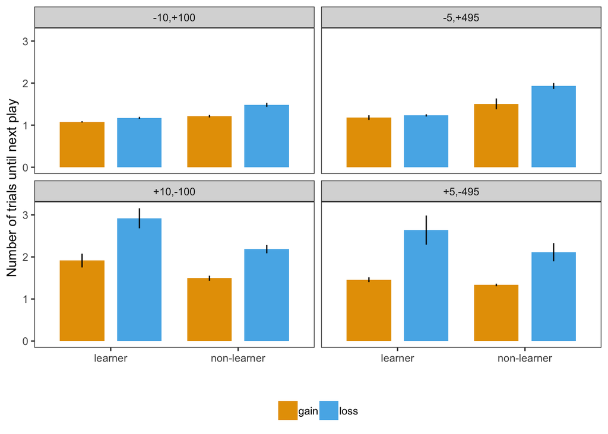

```r
tmp %>%
  group_by(facet_labels, learner, key) %>%
  summarise(mean_post = mean(value, na.rm=T),
            sem_post = sem(value)) %>%
  ggplot(aes(learner, mean_post, fill=key, key=learner))+
  # geom_point(size=2)+
  geom_bar(stat="identity",position = position_dodge(width=0.9), width=0.7)+
  geom_errorbar(aes(ymin = mean_post-sem_post, ymax = mean_post+sem_post), width=0, position = position_dodge(width=0.9))+
  facet_wrap(~facet_labels)+
  ylab("Number of trials until next play")+
  xlab("")+
  theme(legend.title = element_blank())+
  guides(color=FALSE)
```

Everyone takes longer to play after a loss than a gain. This is even more prominent for nEV.

```r
summary(lm(value~key*facet_labels,tmp))
```

```
Call:
lm(formula = value ~ key * facet_labels, data = tmp)

Residuals:
    Min      1Q  Median      3Q     Max
-1.4237 -0.5155 -0.3159 -0.1403 26.5763

Coefficients:
                             Estimate Std. Error t value Pr(>|t|)
(Intercept)                   1.14031    0.03859  29.550  < 2e-16 ***
keyloss                       0.17560    0.05446   3.225  0.00127 **
facet_labels-5,+495           0.17091    0.10625   1.609  0.10776
facet_labels+10,-100          0.49041    0.06803   7.209 6.18e-13 ***
facet_labels+5,-495           0.23844    0.05186   4.598 4.34e-06 ***
keyloss:facet_labels-5,+495   0.02870    0.11761   0.244  0.80724
keyloss:facet_labels+10,-100  0.61736    0.09538   6.473 1.02e-10 ***
keyloss:facet_labels+5,-495   0.75177    0.11818   6.361 2.12e-10 ***
---
Signif. codes:  0 '***' 0.001 '**' 0.01 '*' 0.05 '.' 0.1 ' ' 1

Residual standard error: 1.386 on 7633 degrees of freedom
  (3551 observations deleted due to missingness)
Multiple R-squared:  0.05945,   Adjusted R-squared:  0.05858
F-statistic: 68.92 on 7 and 7633 DF,  p-value: < 2.2e-16
```

And for learners.

```r
summary(lm(value~key*learner,tmp))
```

```
Call:
lm(formula = value ~ key * learner, data = tmp)

Residuals:
    Min      1Q  Median      3Q     Max
-0.8594 -0.4329 -0.3381 -0.3279 27.5671

Coefficients:
                           Estimate Std. Error t value Pr(>|t|)
(Intercept)                 1.32787    0.03547  37.441  < 2e-16 ***
keyloss                     0.10508    0.04719   2.227    0.026 *
learnernon-learner          0.01020    0.04693   0.217    0.828
keyloss:learnernon-learner  0.41627    0.06504   6.400 1.64e-10 ***
---
Signif. codes:  0 '***' 0.001 '**' 0.01 '*' 0.05 '.' 0.1 ' ' 1

Residual standard error: 1.412 on 7637 degrees of freedom
  (3551 observations deleted due to missingness)
Multiple R-squared:  0.02273,   Adjusted R-squared:  0.02235
F-statistic: 59.21 on 3 and 7637 DF,  p-value: < 2.2e-16
```

Does how long a participant thinks before playing affect whether they play after experiencing a loss? Yes. Particularly for learners there is a reverse speed-accuracy tradeoff.

```r
tmp = machine_game_data_clean %>%
  mutate(losstrial = ifelse(Points_earned<0,1,0),
         postloss = lag(losstrial),
         postloss_play1_pass0 = ifelse(postloss == 1 & Response == "play",1, ifelse(postloss==1 & Response == "pass", 0, NA)),
         lastlossamt = lag(Points_earned)) %>%
  filter(postloss==1) %>%
   mutate(learner = ifelse(Sub_id %in% non_learners, "non-learner","learner"))
```

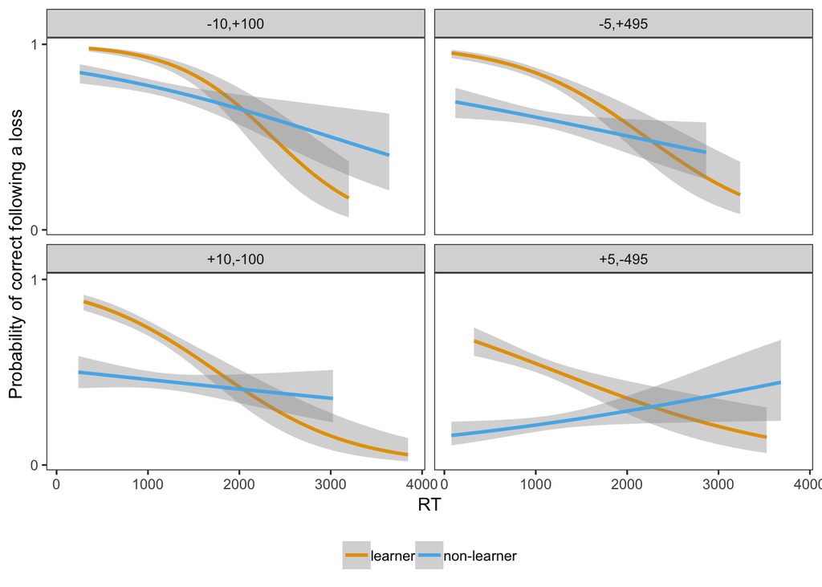

```r
tmp %>%
  ggplot(aes(Reaction_time, correct1_incorrect0))+
  geom_smooth(aes(col=learner), method='glm', method.args = list(family = "binomial"))+
  facet_wrap(~facet_labels)+
  scale_y_continuous(breaks=c(0,1))+
  theme(legend.title = element_blank())+
  xlab("RT")+
  ylab("Probability of correct following a loss")
```

```r
summary(glmer(correct1_incorrect0 ~ scale(Reaction_time)*learner+(1|Sub_id), tmp, family = binomial))
```

```
Generalized linear mixed model fit by maximum likelihood (Laplace
  Approximation) [glmerMod]
 Family: binomial  ( logit )
Formula:
correct1_incorrect0 ~ scale(Reaction_time) * learner + (1 | Sub_id)
   Data: tmp

     AIC      BIC   logLik deviance df.resid
  4763.6   4795.2  -2376.8   4753.6     4061

Scaled residuals:
    Min      1Q  Median      3Q     Max
-3.9825 -0.9155  0.3907  0.7352  2.2932

Random effects:
 Groups Name        Variance Std.Dev.
 Sub_id (Intercept) 0.3132   0.5597
Number of obs: 4066, groups:  Sub_id, 74

Fixed effects:
                                        Estimate Std. Error z value
(Intercept)                              1.16682    0.10947  10.659
scale(Reaction_time)                    -0.71678    0.05834 -12.286
learnernon-learner                      -1.11586    0.15034  -7.422
scale(Reaction_time):learnernon-learner  0.56370    0.07606   7.411
                                        Pr(>|z|)
(Intercept)                              < 2e-16 ***
scale(Reaction_time)                     < 2e-16 ***
learnernon-learner                      1.15e-13 ***
scale(Reaction_time):learnernon-learner 1.25e-13 ***
---
Signif. codes:  0 '***' 0.001 '**' 0.01 '*' 0.05 '.' 0.1 ' ' 1

Correlation of Fixed Effects:
            (Intr) sc(R_) lrnrn-
scl(Rctn_t) -0.056
lrnrnn-lrnr -0.728  0.041
scl(Rct_):-  0.042 -0.766 -0.058
```

### Response time differences

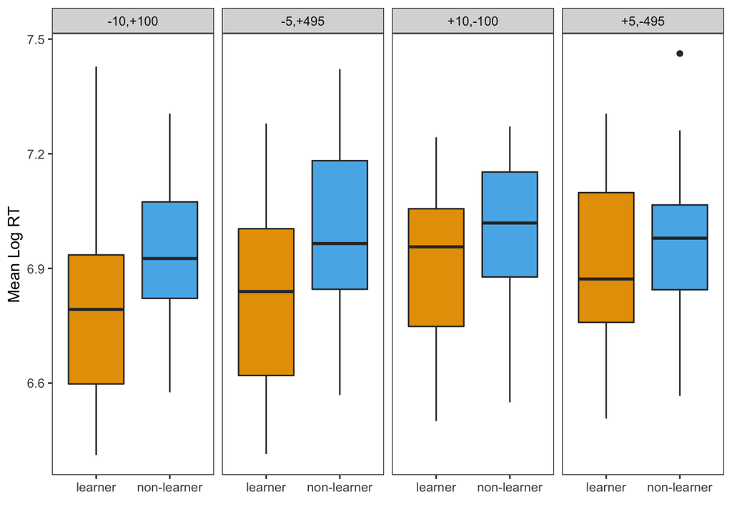

```r
machine_game_data_clean %>%
  group_by(Sub_id, facet_labels) %>%
  summarise(mean_log_rt = mean(log(Reaction_time)),
            sem_log_rt = sem(log(Reaction_time))) %>%
  # do(assign.age.info(.)) %>%
  mutate(learner = ifelse(Sub_id %in% non_learners, "non-learner","learner"))%>%
  ggplot(aes(learner, mean_log_rt))+
  geom_boxplot(aes(fill=learner))+
  facet_grid(~facet_labels)+
  theme(legend.position = "none")+
  ylab("Mean Log RT")+
  xlab("")
```

Learners are faster than non-learners in general. Interactions?

```r
summary(lmer(log(Reaction_time) ~ learner*facet_labels +(1|Sub_id), data = machine_game_data_clean %>% mutate(learner = ifelse(Sub_id %in% non_learners, "non-learner","learner"))))
```

```
Linear mixed model fit by REML ['lmerMod']
Formula: log(Reaction_time) ~ learner * facet_labels + (1 | Sub_id)
   Data: machine_game_data_clean %>% mutate(learner = ifelse(Sub_id %in%
    non_learners, "non-learner", "learner"))

REML criterion at convergence: 14962.4

Scaled residuals:
    Min      1Q  Median      3Q     Max
-6.8405 -0.6773 -0.1037  0.6299  3.8481

Random effects:
 Groups   Name        Variance Std.Dev.
 Sub_id   (Intercept) 0.03319  0.1822
 Residual             0.17639  0.4200
Number of obs: 13290, groups:  Sub_id, 74

Fixed effects:
                                        Estimate Std. Error t value
(Intercept)                              6.79255    0.03211 211.557
learnernon-learner                       0.14080    0.04481   3.142
facet_labels-5,+495                      0.03682    0.01476   2.495
facet_labels+10,-100                     0.11406    0.01476   7.729
facet_labels+5,-495                      0.11831    0.01476   8.018
learnernon-learner:facet_labels-5,+495   0.02590    0.02062   1.256
learnernon-learner:facet_labels+10,-100 -0.04629    0.02062  -2.245
learnernon-learner:facet_labels+5,-495  -0.09419    0.02061  -4.570

Correlation of Fixed Effects:
            (Intr) lrnrn- f_-5,+ f_+10, f_+5,- l-:_-5 l-:_+1
lrnrnn-lrnr -0.716
fct_-5,+495 -0.230  0.165
fc_+10,-100 -0.230  0.165  0.500
fct_+5,-495 -0.230  0.165  0.500  0.500
l-:_-5,+495  0.164 -0.230 -0.716 -0.358 -0.358
l-:_+10,-10  0.164 -0.230 -0.358 -0.716 -0.358  0.500
l-:_+5,-495  0.165 -0.230 -0.358 -0.358 -0.716  0.500  0.500
```

## RL modeling

Details of model comparison can be found in a separate [notebook](http://zenkavi.github.io/DevStudy_Analyses/output/reports/Comp_RL.nb.html).